# Welcome to My Investigate a Dataset project!

# Project: Investigate a Dataset (TMDb Movie Data)

## By Harsh Deep Kalita

- Introduction
- Data Wrangling
- Exploratory Data Analysis
- Conclusions

## Introduction

### TMDb Data Set :

- This data set contains information about 10,000 movies collected from **The Movie Database (TMDb)**,including user ratings and revenue.
- This data set contains : rows = 10866 , columns = 21
- I am going to showcase my data cleaning, wrangling and visualisation (Exploratory Data Analysis) skills using **pandas,numpy, matplotlib and seaborn libraries** in this project.

```python
# packages used
%matplotlib inline
import pandas as pd
import numpy as np
import matplotlib.pyplot as plt
import seaborn as sns
```

## Data Wrangling

> I am going to do the following steps:
- Load the data set into a DataFrame.
- Find the general Properties of the Data Set.
- Find the duplicate rows and drop them.
- Find the null values or odd characters present in specific columns and, either drop them or fill them with appropriate values(eg: mean).
- Find the attributes which are not useful for extracting insights from our dataset and drop them.

```python
df_tmdb = pd.read_csv('tmdb-movies.csv')
df_tmdb.head(1)
```

|  | id | imdb_id | popularity | budget | revenue | original_title | cast | homepage | director | tagline | ... | overview | runtime | genres | production_companies | release_date | vote_count | vote_average | release_year | budget_adj | revenue_adj |
| --- | --- | --- | --- | --- | --- | --- | --- | --- | --- | --- | --- | --- | --- | --- | --- | --- | --- | --- | --- | --- | --- |
| 0 | 135397 | tt0369610 | 32.985763 | 150000000 | 1513528810 | Jurassic World | Chris Pratt\|Bryce Dallas Howard\|Irrfan Khan\|Vi... | http://www.jurassicworld.com/ | Colin Trevorrow | The park is open. | ... | Twenty-two years after the events of Jurassic ... | 124 | Action\|Adventure\|Science Fiction\|Thriller | Universal Studios\|Amblin Entertainment\|Legenda... | 6/9/15 | 5562 | 6.5 | 2015 | 1.379999e+08 | 1.392446e+09 |

1 rows × 21 columns

## General Properties:

Before Data Cleaning

```python
df_tmdb.shape
```

```
(10866, 21)
```

```python
df_tmdb.nunique()
```

```
id                      10865
imdb_id                 10855
popularity              10814
budget                    557
revenue                  4702
original_title          10571
cast                    10719
homepage                 2896
director                 5067
tagline                  7997
keywords                 8804
overview                10847
runtime                   247
genres                   2039
production_companies     7445
release_date             5909
vote_count               1289
vote_average               72
release_year               56
budget_adj               2614
revenue_adj              4840
dtype: int64
```

```python
df_tmdb.info();
```

```
<class 'pandas.core.frame.DataFrame'>
RangeIndex: 10866 entries, 0 to 10865
Data columns (total 21 columns):
 #   Column                Non-Null Count  Dtype
---  ------                --------------  -----
 0   id                    10866 non-null  int64
 1   imdb_id               10856 non-null  object
 2   popularity            10866 non-null  float64
 3   budget                10866 non-null  int64
 4   revenue               10866 non-null  int64
 5   original_title        10866 non-null  object
 6   cast                  10790 non-null  object
 7   homepage              2936 non-null   object
 8   director              10822 non-null  object
 9   tagline               8042 non-null   object
 10  keywords              9373 non-null   object
 11  overview              10862 non-null  object
 12  runtime               10866 non-null  int64
 13  genres                10843 non-null  object
 14  production_companies  9836 non-null   object
 15  release_date          10866 non-null  object
 16  vote_count            10866 non-null  int64
 17  vote_average          10866 non-null  float64
 18  release_year          10866 non-null  int64
 19  budget_adj            10866 non-null  float64
 20  revenue_adj           10866 non-null  float64
dtypes: float64(4), int64(6), object(11)
memory usage: 1.7+ MB
```

### Delete the missing values

```python
df_tmdb.isnull().sum()
```

```
id                         0
imdb_id                   10
popularity                 0
budget                     0
revenue                    0
original_title             0
cast                      76
homepage                7930
director                  44
tagline                 2824
keywords                1493
overview                   4
runtime                    0
genres                    23
production_companies    1030
release_date               0
vote_count                 0
vote_average               0
release_year               0
budget_adj                 0
revenue_adj                0
dtype: int64
```

```python
df_tmdb[df_tmdb.isnull().any(axis=1)].head()
```

|  | id | imdb_id | popularity | budget | revenue | original_title | cast | homepage | director | tagline | ... | overview | runtime | genres | production_companies | release_date | vote_count | vote_average | release_year | budget_adj | revenue_adj |
| --- | --- | --- | --- | --- | --- | --- | --- | --- | --- | --- | --- | --- | --- | --- | --- | --- | --- | --- | --- | --- | --- |
| 18 | 150689 | tt1661199 | 5.556818 | 95000000 | 542351353 | Cinderella | Lily James\|Cate Blanchett\|Richard Madden\|Helen... | NaN | Kenneth Branagh | Midnight is just the beginning. | ... | When her father unexpectedly passes away, youn... | 112 | Romance\|Fantasy\|Family\|Drama | Walt Disney Pictures\|Genre Films\|Beagle Pug Fi... | 3/12/15 | 1495 | 6.8 | 2015 | 8.739996e+07 | 4.989630e+08 |
| 21 | 307081 | tt1798684 | 5.337064 | 30000000 | 91709827 | Southpaw | Jake Gyllenhaal\|Rachel McAdams\|Forest Whitaker... | NaN | Antoine Fuqua | Believe in Hope. | ... | Billy "The Great" Hope, the reigning junior mi... | 123 | Action\|Drama | Escape Artists\|Riche-Ludwig Productions | 6/15/15 | 1386 | 7.3 | 2015 | 2.759999e+07 | 8.437300e+07 |
| 26 | 214756 | tt2637276 | 4.564549 | 68000000 | 215863606 | Ted 2 | Mark Wahlberg\|Seth MacFarlane\|Amanda Seyfried\|... | NaN | Seth MacFarlane | Ted is Coming, Again. | ... | Newlywed couple Ted and Tami-Lynn want to have... | 115 | Comedy | Universal Pictures\|Media Rights Capital\|Fuzzy ... | 6/25/15 | 1666 | 6.3 | 2015 | 6.255997e+07 | 1.985944e+08 |
| 32 | 254470 | tt2848292 | 3.877764 | 29000000 | 287506194 | Pitch Perfect 2 | Anna Kendrick\|Rebel Wilson\|Hailee Steinfeld\|Br... | NaN | Elizabeth Banks | We're back pitches | ... | The Bellas are back, and they are better than ... | 115 | Comedy\|Music | Universal Pictures\|Gold Circle Films\|Brownston... | 5/7/15 | 1264 | 6.8 | 2015 | 2.667999e+07 | 2.645056e+08 |
| 33 | 296098 | tt3682448 | 3.648210 | 40000000 | 162610473 | Bridge of Spies | Tom Hanks\|Mark Rylance\|Amy Ryan\|Alan Alda\|Seba... | NaN | Steven Spielberg | In the shadow of war, one man showed the world... | ... | During the Cold War, the Soviet Union captures... | 141 | Thriller\|Drama | DreamWorks SKG\|Amblin Entertainment\|Studio Bab... | 10/15/15 | 1638 | 7.1 | 2015 | 3.679998e+07 | 1.496016e+08 |

5 rows × 21 columns

#### As homepage has 72% of it's values missing and the attribute is not coming into picture while finding the insights from the data set. Hence, I dropped the column homepage.

```python
df_tmdb.drop(['homepage'],axis = 1,inplace = True)
```

#### Deleted other necessary attributes which were not useful for the Exploratory Data Analysis

```python
df_tmdb.drop(['tagline','keywords','overview','budget_adj','revenue_adj','id'],axis = 1,inplace = True)
# the required attributes for finding the insights
df_tmdb.columns
```

```
Index(['imdb_id', 'popularity', 'budget', 'revenue', 'original_title', 'cast',
       'director', 'runtime', 'genres', 'production_companies', 'release_date',
       'vote_count', 'vote_average', 'release_year'],
      dtype='object')
```

```python
df_tmdb.dropna(inplace = True)
```

```python
df_tmdb[df_tmdb.isnull().any(axis=1)].head()
```

|  | imdb_id | popularity | budget | revenue | original_title | cast | director | runtime | genres | production_companies | release_date | vote_count | vote_average | release_year |
| --- | --- | --- | --- | --- | --- | --- | --- | --- | --- | --- | --- | --- | --- | --- |

#### No Null Values present in the Data Set

```python
df_tmdb.isnull().sum()
```

```
imdb_id                 0
popularity              0
budget                  0
revenue                 0
original_title          0
cast                    0
director                0
runtime                 0
genres                  0
production_companies    0
release_date            0
vote_count              0
vote_average            0
release_year            0
dtype: int64
```

```python
df_tmdb.head()
```

|  | imdb_id | popularity | budget | revenue | original_title | cast | director | runtime | genres | production_companies | release_date | vote_count | vote_average | release_year |
| --- | --- | --- | --- | --- | --- | --- | --- | --- | --- | --- | --- | --- | --- | --- |
| 0 | tt0369610 | 32.985763 | 150000000 | 1513528810 | Jurassic World | Chris Pratt\|Bryce Dallas Howard\|Irrfan Khan\|Vi... | Colin Trevorrow | 124 | Action\|Adventure\|Science Fiction\|Thriller | Universal Studios\|Amblin Entertainment\|Legenda... | 6/9/15 | 5562 | 6.5 | 2015 |
| 1 | tt1392190 | 28.419936 | 150000000 | 378436354 | Mad Max: Fury Road | Tom Hardy\|Charlize Theron\|Hugh Keays-Byrne\|Nic... | George Miller | 120 | Action\|Adventure\|Science Fiction\|Thriller | Village Roadshow Pictures\|Kennedy Miller Produ... | 5/13/15 | 6185 | 7.1 | 2015 |
| 2 | tt2908446 | 13.112507 | 110000000 | 295238201 | Insurgent | Shailene Woodley\|Theo James\|Kate Winslet\|Ansel... | Robert Schwentke | 119 | Adventure\|Science Fiction\|Thriller | Summit Entertainment\|Mandeville Films\|Red Wago... | 3/18/15 | 2480 | 6.3 | 2015 |
| 3 | tt2488496 | 11.173104 | 200000000 | 2068178225 | Star Wars: The Force Awakens | Harrison Ford\|Mark Hamill\|Carrie Fisher\|Adam D... | J.J. Abrams | 136 | Action\|Adventure\|Science Fiction\|Fantasy | Lucasfilm\|Truenorth Productions\|Bad Robot | 12/15/15 | 5292 | 7.5 | 2015 |
| 4 | tt2820852 | 9.335014 | 190000000 | 1506249360 | Furious 7 | Vin Diesel\|Paul Walker\|Jason Statham\|Michelle ... | James Wan | 137 | Action\|Crime\|Thriller | Universal Pictures\|Original Film\|Media Rights ... | 4/1/15 | 2947 | 7.3 | 2015 |

There are columns: runtime,budget and revenue containing zero as value.

```python
budget_0 = df_tmdb.query('budget == 0')
revenue_0 = df_tmdb.query('revenue == 0')
print("number of rows with revenue == 0 are ",revenue_0.value_counts().sum())
print("number of rows with budget == 0 are ",budget_0.value_counts().sum())
```

```
number of rows with revenue == 0 are  5020
number of rows with budget == 0 are  4749
```

```python
df_tmdb.isnull().sum()
```

```
imdb_id                 0
popularity              0
budget                  0
revenue                 0
original_title          0
cast                    0
director                0
runtime                 0
genres                  0
production_companies    0
release_date            0
vote_count              0
vote_average            0
release_year            0
dtype: int64
```

```python
df_tmdb.info()
```

```
<class 'pandas.core.frame.DataFrame'>
Int64Index: 9771 entries, 0 to 10865
Data columns (total 14 columns):
 #   Column                Non-Null Count  Dtype
---  ------                --------------  -----
 0   imdb_id               9771 non-null   object
 1   popularity            9771 non-null   float64
 2   budget                9771 non-null   int64
 3   revenue               9771 non-null   int64
 4   original_title        9771 non-null   object
 5   cast                  9771 non-null   object
 6   director              9771 non-null   object
 7   runtime               9771 non-null   int64
 8   genres                9771 non-null   object
 9   production_companies  9771 non-null   object
 10  release_date          9771 non-null   object
 11  vote_count            9771 non-null   int64
 12  vote_average          9771 non-null   float64
 13  release_year          9771 non-null   int64
dtypes: float64(2), int64(5), object(7)
memory usage: 1.1+ MB
```

### Remove duplicates (if any)

```python
df_tmdb.duplicated().sum()
```

```
1
```

```python
df_tmdb.drop_duplicates(inplace = True)
df_tmdb.duplicated().sum()
```

```
0
```

```python
df_tmdb.shape
```

```
(9770, 14)
```

### Data Cleaning

- Checking the Data Types is one of the most important steps in the Data Cleaning process.
- It helps in improving the Visualisations.
- Changed the release_date to datetime64[ns] format

```python
df_tmdb.dtypes
```

```
imdb_id                  object
popularity              float64
budget                    int64
revenue                   int64
original_title           object
cast                     object
director                 object
runtime                   int64
genres                   object
production_companies     object
release_date             object
vote_count                int64
vote_average            float64
release_year              int64
dtype: object
```

```python
columns = ['cast','genres','production_companies']
for i in columns:
    df_tmdb[i] = df_tmdb[i].str.replace('|',',');
df_tmdb.head()
```

[output not shown]

|  | imdb_id | popularity | budget | revenue | original_title | cast | director | runtime | genres | production_companies | release_date | vote_count | vote_average | release_year |
| --- | --- | --- | --- | --- | --- | --- | --- | --- | --- | --- | --- | --- | --- | --- |
| 0 | tt0369610 | 32.985763 | 150000000 | 1513528810 | Jurassic World | Chris Pratt,Bryce Dallas Howard,Irrfan Khan,Vi... | Colin Trevorrow | 124 | Action,Adventure,Science Fiction,Thriller | Universal Studios,Amblin Entertainment,Legenda... | 6/9/15 | 5562 | 6.5 | 2015 |
| 1 | tt1392190 | 28.419936 | 150000000 | 378436354 | Mad Max: Fury Road | Tom Hardy,Charlize Theron,Hugh Keays-Byrne,Nic... | George Miller | 120 | Action,Adventure,Science Fiction,Thriller | Village Roadshow Pictures,Kennedy Miller Produ... | 5/13/15 | 6185 | 7.1 | 2015 |
| 2 | tt2908446 | 13.112507 | 110000000 | 295238201 | Insurgent | Shailene Woodley,Theo James,Kate Winslet,Ansel... | Robert Schwentke | 119 | Adventure,Science Fiction,Thriller | Summit Entertainment,Mandeville Films,Red Wago... | 3/18/15 | 2480 | 6.3 | 2015 |
| 3 | tt2488496 | 11.173104 | 200000000 | 2068178225 | Star Wars: The Force Awakens | Harrison Ford,Mark Hamill,Carrie Fisher,Adam D... | J.J. Abrams | 136 | Action,Adventure,Science Fiction,Fantasy | Lucasfilm,Truenorth Productions,Bad Robot | 12/15/15 | 5292 | 7.5 | 2015 |
| 4 | tt2820852 | 9.335014 | 190000000 | 1506249360 | Furious 7 | Vin Diesel,Paul Walker,Jason Statham,Michelle ... | James Wan | 137 | Action,Crime,Thriller | Universal Pictures,Original Film,Media Rights ... | 4/1/15 | 2947 | 7.3 | 2015 |

```python
df_tmdb['release_date'] = pd.to_datetime(df_tmdb['release_date'])
```

```python
df_tmdb.dtypes
```

```
imdb_id                         object
popularity                     float64
budget                           int64
revenue                          int64
original_title                  object
cast                            object
director                        object
runtime                          int64
genres                          object
production_companies            object
release_date            datetime64[ns]
vote_count                       int64
vote_average                   float64
release_year                     int64
dtype: object
```

```python
df_tmdb.describe()
```

|  | popularity | budget | revenue | runtime | vote_count | vote_average | release_year |
| --- | --- | --- | --- | --- | --- | --- | --- |
| count | 9770.000000 | 9.770000e+03 | 9.770000e+03 | 9770.000000 | 9770.000000 | 9770.000000 | 9770.000000 |
| mean | 0.694775 | 1.618298e+07 | 4.424026e+07 | 102.939611 | 239.353224 | 5.963388 | 2000.876766 |
| std | 1.037027 | 3.221320e+07 | 1.225998e+08 | 27.865500 | 603.066348 | 0.913207 | 13.037610 |
| min | 0.000188 | 0.000000e+00 | 0.000000e+00 | 0.000000 | 10.000000 | 1.500000 | 1960.000000 |
| 25% | 0.232620 | 0.000000e+00 | 0.000000e+00 | 90.000000 | 18.000000 | 5.400000 | 1994.000000 |
| 50% | 0.419762 | 2.000000e+05 | 0.000000e+00 | 100.000000 | 46.000000 | 6.000000 | 2005.000000 |
| 75% | 0.776465 | 1.936250e+07 | 3.105779e+07 | 112.000000 | 173.000000 | 6.600000 | 2011.000000 |
| max | 32.985763 | 4.250000e+08 | 2.781506e+09 | 877.000000 | 9767.000000 | 8.700000 | 2015.000000 |

### Univariate Analysis

```python
def uni_info (arg):
    print('mean of ',arg,': ',clean_df_tmdb[arg].mean())
    print('median of ',arg,': ',clean_df_tmdb[arg].median())
    print('standard deviation of ',arg,': ',clean_df_tmdb[arg].std())
```

### Popularity

```python
uni_info('popularity')
```

```
mean of  popularity :  0.6947746159672465
median of  popularity :  0.41976199999999997
standard deviation of  popularity :  1.0370273893935567
```

#### As the standard deviation (popularity) is larger than mean (popularity)

#### Hence,The popularity variable's data is highly spread out which means high variation in data.

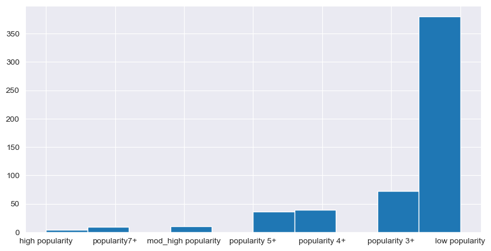

```python
bin_edges = [2,3.5,4.5,5.5,6.5,7.5,8.5,9]
bin_names = ['low popularity','popularity 3+','popularity 4+','popularity 5+','mod_high popularity','popularity7+','high popularity']
pd.cut(clean_df_tmdb['popularity'],bin_edges,labels = bin_names).hist(figsize=(10,5));
```

### Mean, Median and Standard Deviation of budget, revenue, vote_average and vote_count variables

- Variation in data would be really high for budget,revenue and vote_count as the standard deviation is larger than the mean.
- Budget = the distribution is Positively Skewed
- Revenue = the distribution is Positively Skewed
- Vote Average = the data is Normally Distributed
- Vote Count = the distribution is Positively Skewed

```python
uni_info('budget')
```

```
mean of  budget :  16182980.033879222
median of  budget :  200000.0
standard deviation of  budget :  32213202.71456747
```

```python
uni_info('revenue')
```

```
mean of  revenue :  44240263.388741046
median of  revenue :  0.0
standard deviation of  revenue :  122599810.34450924
```

```python
uni_info('vote_average')
```

```
mean of  vote_average :  5.963387922210857
median of  vote_average :  6.0
standard deviation of  vote_average :  0.9132073011967508
```

```python
uni_info('vote_count')
```

```
mean of  vote_count :  239.3532241555783
median of  vote_count :  46.0
standard deviation of  vote_count :  603.0663477253318
```

### We can see that there are many outliers in this data set

- In released_date we have frequency of data increasing in the year of 2060(These are outliers).
- Popularity, budget,vote_count,runtime and revenue have many outliers too.

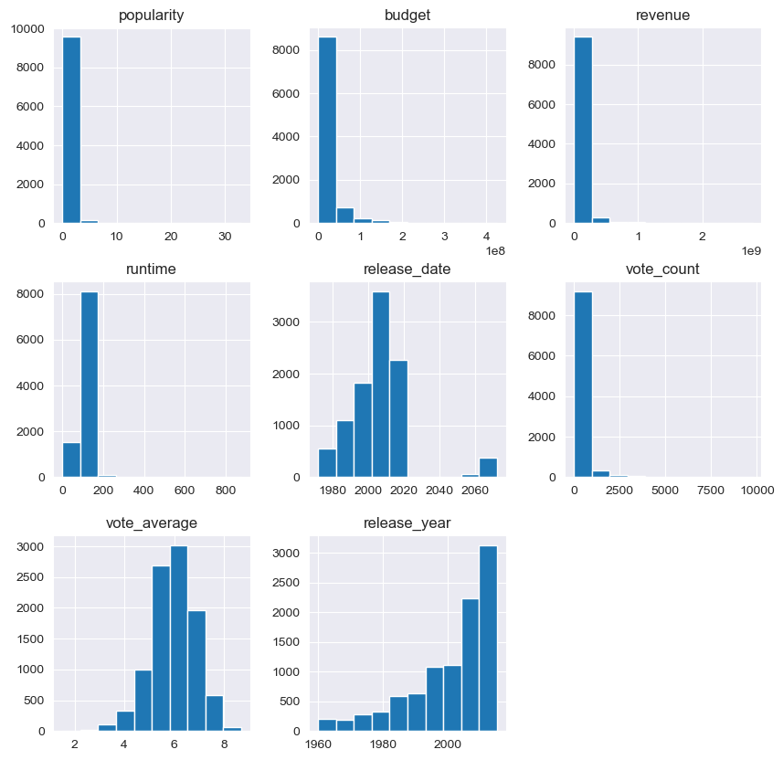

```python
df_tmdb.hist(figsize=(10,10));
```

#### Save the Data Set after the Data Wrangling Process

Now I'll use this data set for The Exploratory Data Analysis part.

```python
df_tmdb.to_csv('clean_df_tmdb.csv')
```

### I always like keeping a backup of the Data set 😀

```python
df_tmdb.to_csv('clean_df_tmdb_backup.csv')
clean_df_tmdb_backup = pd.read_csv('clean_df_tmdb_backup.csv')
```

## Exploratory Data Analysis

> Questions:
- Which Genre Has The Highest Release Of Movies?
- Which year has the highest release of movies?
- Who are the Top 10 Directors with highest number of movies (From 1960 - 2015) ?
- What are the Top 10 and Bottom 10 Movies according to the ratings of the viewers?
- Which Movies have the highest profit and loss?
- Which length movies are most liked by the audiences according to popularity?
- What are the Average Budget Of Movies From Year To Year?
- Do movies with higher budget have higher profit?
- What kinds of properties are associated with movies that have high revenues?
- Which month released highest number of movies in all years ?
- Which Month Made The Highest Average Revenue?

```python
clean_df_tmdb = pd.read_csv('clean_df_tmdb.csv')
del clean_df_tmdb['Unnamed: 0']
clean_df_tmdb.head()
```

|  | imdb_id | popularity | budget | revenue | original_title | cast | director | runtime | genres | production_companies | release_date | vote_count | vote_average | release_year |
| --- | --- | --- | --- | --- | --- | --- | --- | --- | --- | --- | --- | --- | --- | --- |
| 0 | tt0369610 | 32.985763 | 150000000 | 1513528810 | Jurassic World | Chris Pratt,Bryce Dallas Howard,Irrfan Khan,Vi... | Colin Trevorrow | 124 | Action,Adventure,Science Fiction,Thriller | Universal Studios,Amblin Entertainment,Legenda... | 2015-06-09 | 5562 | 6.5 | 2015 |
| 1 | tt1392190 | 28.419936 | 150000000 | 378436354 | Mad Max: Fury Road | Tom Hardy,Charlize Theron,Hugh Keays-Byrne,Nic... | George Miller | 120 | Action,Adventure,Science Fiction,Thriller | Village Roadshow Pictures,Kennedy Miller Produ... | 2015-05-13 | 6185 | 7.1 | 2015 |
| 2 | tt2908446 | 13.112507 | 110000000 | 295238201 | Insurgent | Shailene Woodley,Theo James,Kate Winslet,Ansel... | Robert Schwentke | 119 | Adventure,Science Fiction,Thriller | Summit Entertainment,Mandeville Films,Red Wago... | 2015-03-18 | 2480 | 6.3 | 2015 |
| 3 | tt2488496 | 11.173104 | 200000000 | 2068178225 | Star Wars: The Force Awakens | Harrison Ford,Mark Hamill,Carrie Fisher,Adam D... | J.J. Abrams | 136 | Action,Adventure,Science Fiction,Fantasy | Lucasfilm,Truenorth Productions,Bad Robot | 2015-12-15 | 5292 | 7.5 | 2015 |
| 4 | tt2820852 | 9.335014 | 190000000 | 1506249360 | Furious 7 | Vin Diesel,Paul Walker,Jason Statham,Michelle ... | James Wan | 137 | Action,Crime,Thriller | Universal Pictures,Original Film,Media Rights ... | 2015-04-01 | 2947 | 7.3 | 2015 |

### Q1.Which Genre Has The Highest Release Of Movies?

```python
h1 = clean_df_tmdb.copy()
col = ['genres']
for i in col:
    h1[i] = h1[i].apply(lambda x:x.split(",")[0])
```

```python
h1.genres.value_counts()
```

```
Drama              2223
Comedy             2084
Action             1478
Horror              853
Adventure           550
Thriller            474
Crime               361
Animation           345
Documentary         264
Fantasy             253
Science Fiction     196
Romance             161
Family              128
Mystery             118
Music                79
TV Movie             59
War                  57
Western              42
History              39
Foreign               6
Name: genres, dtype: int64
```

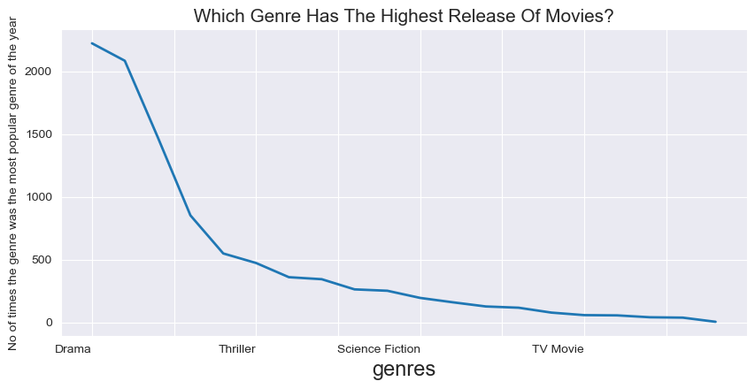

```python
sns.set_style("darkgrid")
plt.xlabel('genres',fontsize=17)
plt.ylabel('No of times the genre was the most popular genre of the year',fontsize= 10)
plt.title(' Which Genre Has The Highest Release Of Movies? ',fontsize=15)
plt.xticks(rotation=15, ha='right')
h1.genres.value_counts().plot(kind = 'line',figsize=(10,4.5),linewidth=2);
```

### Answer: According to the above line chart we can say that "Drama" had the highest number of release of movies.

### Q2. Which year has the highest release of movies?

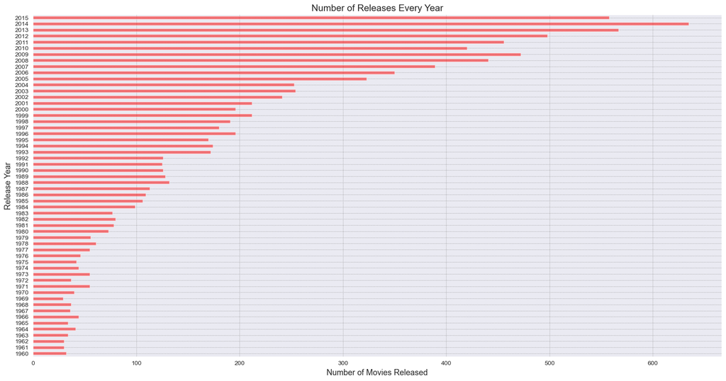

```python
bar_kwargs = {'color':'red', 'alpha':0.5}
clean_df_tmdb.groupby('release_year')['imdb_id'].count().plot(kind='barh',figsize=(20,10),**bar_kwargs);
plt.ylabel('Release Year',fontsize=13);
plt.xlabel('Number of Movies Released',fontsize=13);
plt.title('Number of Releases Every Year',fontsize=15);
```

### Answer: Highest Release of Movies were made in the year 2014.

### Q3. Top 10 Director with highest number of movies (From 1960 - 2015) ?

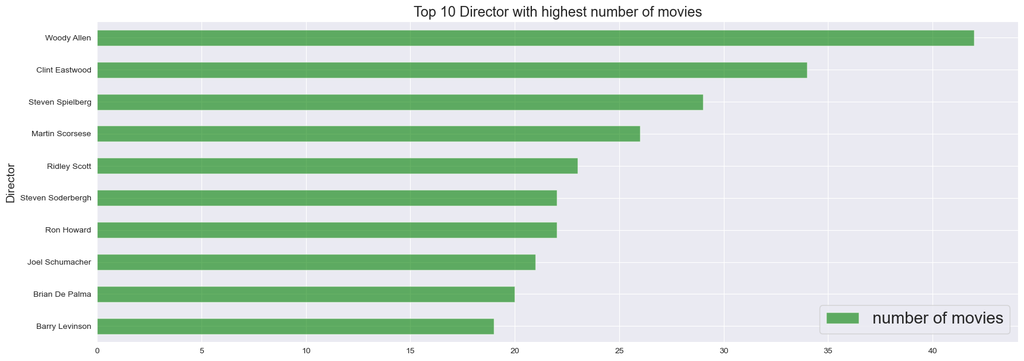

```python
director_high = clean_df_tmdb.director.value_counts().head(10)
director_high.sort_values().plot(kind = 'barh',alpha = 0.6,color = 'green',figsize=(20,7))
sns.set_style("darkgrid",{"grid.color": ".6", "grid.linestyle": ":"})
plt.legend(['number of movies'],fontsize=20);
plt.title('Top 10 Director with highest number of movies',fontsize=17);
plt.ylabel('Director',fontsize=14);
```

### Q4. What are the Top 10 and Bottom 10 Movies according to the ratings of the viewers?

```python
tmdb_rate = clean_df_tmdb.sort_values(by = ['vote_average'],ascending = False)
tmdb_high_rate = tmdb_rate.head(10)
tmdb_low_rate = tmdb_rate.tail(10)
```

#### Top 10 Movies according to the ratings of the viewers

```python
tmdb_high_rate.reset_index(drop=True).iloc[:,np.r_[4:5,-2:-1]]
```

|  | original_title | vote_average |
| --- | --- | --- |
| 0 | Pink Floyd: Pulse | 8.7 |
| 1 | Queen - Rock Montreal | 8.5 |
| 2 | A Personal Journey with Martin Scorsese Throug... | 8.5 |
| 3 | The Art of Flight | 8.5 |
| 4 | Guten Tag, RamÃ³n | 8.4 |
| 5 | Stop Making Sense | 8.4 |
| 6 | The Jinx: The Life and Deaths of Robert Durst | 8.4 |
| 7 | The Shawshank Redemption | 8.4 |
| 8 | Iron Maiden: Flight 666 | 8.3 |
| 9 | Dear Zachary: A Letter to a Son About His Father | 8.3 |

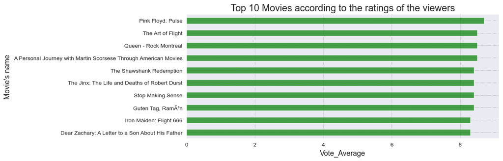

```python
y = tmdb_high_rate.groupby('original_title')['vote_average'].mean()
y.sort_values().plot(kind = 'barh',color = 'green',alpha = 0.7,figsize=(10,4));

plt.ylabel("Movie's name",fontsize=13)
plt.xlabel('Vote_Average',fontsize=13)
plt.title('Top 10 Movies according to the ratings of the viewers',fontsize=17);
```

#### Bottom 10 Movies according to the ratings of the viewers

```python
tmdb_low_rate.reset_index(drop=True).iloc[:,np.r_[4:5,-2:-1]]
```

|  | original_title | vote_average |
| --- | --- | --- |
| 0 | Age of Tomorrow | 2.4 |
| 1 | Dracula 3000 | 2.3 |
| 2 | The Sleeper | 2.2 |
| 3 | Foodfight! | 2.2 |
| 4 | Atlantic Rim | 2.2 |
| 5 | Sand Sharks | 2.1 |
| 6 | Superbabies: Baby Geniuses 2 | 2.1 |
| 7 | Jurassic Shark | 2.0 |
| 8 | Transmorphers | 1.5 |
| 9 | Manos: The Hands of Fate | 1.5 |

```python
def chart(arg,colors):
    tmdb_low_rate.groupby('original_title')['vote_average'].sum().sort_values().plot(kind = arg ,color = colors,alpha = 0.6,figsize=(10,3));
    plt.xticks(rotation=25, ha='right')
    plt.xlabel("Movie's name",fontsize=10)
    plt.title('Bottom 10 Movies according to the ratings of the viewers',fontsize=15);
```

[figure not shown]

```python
chart('line','black')
chart('bar','red')
plt.legend(['vote average']);
```

### Q5. Which Movies have the highest profit and loss?

#### Feature Engineering: Profit = Revenue - Budget

```python
clean_df_tmdb['profit'] = clean_df_tmdb.revenue - clean_df_tmdb.budget
```

```python
profit = clean_df_tmdb.sort_values(by = 'profit',ascending = False).head(10)
profit.iloc[:,np.r_[4:5,14:15]]
```

|  | original_title | profit |
| --- | --- | --- |
| 1242 | Avatar | 2544505847 |
| 3 | Star Wars: The Force Awakens | 1868178225 |
| 4620 | Titanic | 1645034188 |
| 0 | Jurassic World | 1363528810 |
| 4 | Furious 7 | 1316249360 |
| 3869 | The Avengers | 1299557910 |
| 3001 | Harry Potter and the Deathly Hallows: Part 2 | 1202817822 |
| 14 | Avengers: Age of Ultron | 1125035767 |
| 4800 | Frozen | 1124219009 |
| 7153 | The Net | 1084279658 |

```python
loss = clean_df_tmdb.sort_values(by = 'profit',ascending = True).head(10)
loss.iloc[:,np.r_[4:5,14:15]]
```

|  | original_title | profit |
| --- | --- | --- |
| 2025 | The Warrior's Way | -413912431 |
| 4886 | The Lone Ranger | -165710090 |
| 1863 | The Wolfman | -150000000 |
| 2000 | The Pacific | -120000000 |
| 6210 | The Alamo | -119180039 |
| 3111 | Mars Needs Moms | -111007242 |
| 1979 | Double Wedding | -104002432 |
| 1541 | Dragonball Evolution | -100000000 |
| 4387 | Brother Bear | -99999750 |
| 2161 | The 13th Warrior | -98301101 |

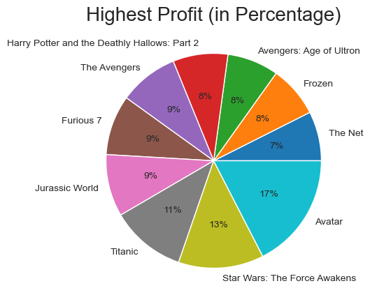

```python
x = profit.groupby('original_title')['profit'].mean()
proportional = x/x.sum()
proportional.sort_values().plot(kind='pie',figsize=(15,5),autopct='%1.0f%%');
plt.title('Highest Profit (in Percentage)',fontsize=20)
plt.ylabel('',fontsize=15);
```

### Movie: "Avatar" has the Highest Profit

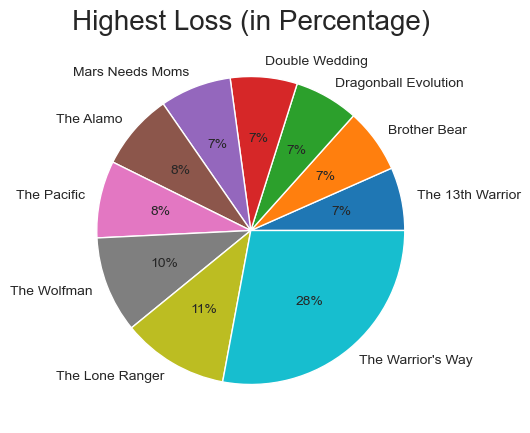

```python
y = loss.groupby('original_title')['profit'].mean()
y = y/y.sum()
y.sort_values().plot(kind='pie',figsize=(15,5), autopct='%1.0f%%');
plt.ylabel('',fontsize=15)
plt.title('Highest Loss (in Percentage)',fontsize=20);
```

### Movie: "The Warrior's Way" has the Highest Loss

### Q6. Which length movies are most liked by the audiences according to popularity?

#### The Audience has liked the Movies with the Duration between 100 to 200 mins

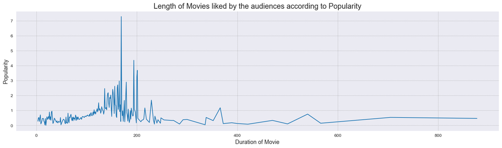

```python
clean_df_tmdb.groupby('runtime')['popularity'].mean().plot(kind='line',figsize=(20,5));
sns.set_style("darkgrid",{"grid.color": ".6", "grid.linestyle": ":"})
plt.xlabel('Duration of Movie',fontsize=13)
plt.ylabel('Popularity',fontsize=13)
plt.title('Length of Movies liked by the audiences according to Popularity',fontsize=17);
```

#### More precisely, 169 mins (2.8 hours) of movie duration has the maximum popularity

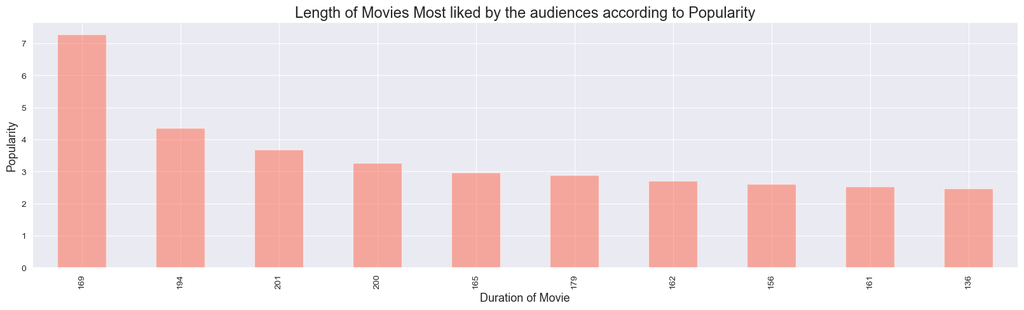

```python
bar_kwargs = {'color':'tomato', 'alpha':0.5}
clean_df_tmdb.groupby('runtime')['popularity'].mean().sort_values(ascending=False).head(10).plot(kind='bar',figsize=(20,5),**bar_kwargs)
plt.xlabel('Duration of Movie',fontsize=13)
plt.ylabel('Popularity',fontsize=13)
plt.title('Length of Movies Most liked by the audiences according to Popularity',fontsize=17);
```

### Q7. Average Budget and Revenue Of Movies From Year To Year?

### Between 1990 to 2000 there was a huge increase in the average budget of the movies, after that we can notice some fluctuations (decreasing trend).

```python
def  avg_bud_rev(arg,color):
    x = clean_df_tmdb.groupby('release_year')[arg].mean()
    proportion = x/x.sum()
    proportion.plot(kind = 'line',figsize=(10,4.5),color = color,lw=0.7, marker='.');
    plt.xlabel('Release Year',fontsize=14)
    plt.ylabel('Budget|Revenue',fontsize=14);
    plt.title('Average Budget and Revenue Of Movies From Year To Year',fontsize=18);
```

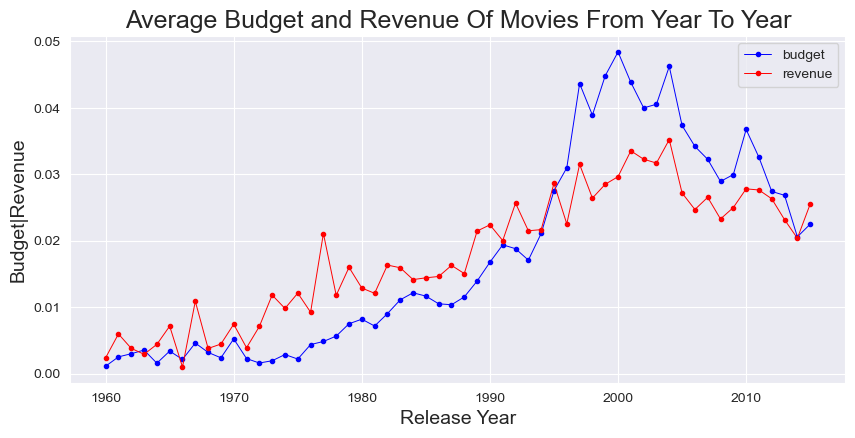

```python
avg_bud_rev('budget','blue')
avg_bud_rev('revenue','red')
plt.legend(['budget','revenue']);
```

### We can observe the trend of the Budget and Revenue is similar (They are related to each other).

### Q8. Do movies with higher budget have higher profit?

I Created a bar chart with one bar for low budget and one bar for high budget movies.

#### Feature Engineering: Profit = Revenue - Budget

```python
clean_df_tmdb['profit'] = clean_df_tmdb.revenue - clean_df_tmdb.budget
```

```python
mean = clean_df_tmdb['budget'].mean()
low = clean_df_tmdb.query('budget < {}'.format(mean))
high = clean_df_tmdb.query('budget >= {}'.format(mean))

mean_rating_low = low['profit'].mean() / low['profit'].sum()
mean_rating_high = high['profit'].mean() / high['profit'].sum()
```

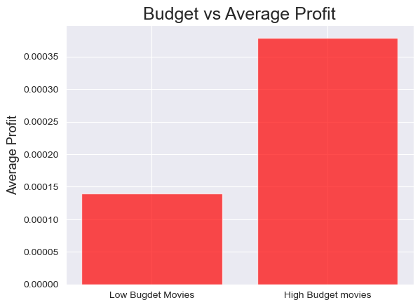

```python
locations = [1,2]
heights = [mean_rating_low, mean_rating_high]
labels = ['Low Bugdet Movies', 'High Budget movies']
plt.bar( locations,heights, tick_label=labels,color=['red'],alpha = 0.7);
plt.ylabel('Average Profit',fontsize=13)
plt.title('Budget vs Average Profit',fontsize=18);
```

### Q9. What kinds of properties are associated with movies that have high revenues?

```python
high_revenue = clean_df_tmdb.query('revenue >= 44294767.40192662')
```

```python
high_revenue.corr(method = 'pearson')
```

|  | popularity | budget | revenue | runtime | vote_count | vote_average | release_year |
| --- | --- | --- | --- | --- | --- | --- | --- |
| popularity | 1.000000 | 0.383008 | 0.562961 | 0.168423 | 0.745242 | 0.346015 | 0.207668 |
| budget | 0.383008 | 1.000000 | 0.632547 | 0.190434 | 0.514028 | -0.009727 | 0.362223 |
| revenue | 0.562961 | 0.632547 | 1.000000 | 0.196986 | 0.719025 | 0.243236 | 0.168716 |
| runtime | 0.168423 | 0.190434 | 0.196986 | 1.000000 | 0.241432 | 0.374839 | -0.104487 |
| vote_count | 0.745242 | 0.514028 | 0.719025 | 0.241432 | 1.000000 | 0.445861 | 0.264348 |
| vote_average | 0.346015 | -0.009727 | 0.243236 | 0.374839 | 0.445861 | 1.000000 | -0.125810 |
| release_year | 0.207668 | 0.362223 | 0.168716 | -0.104487 | 0.264348 | -0.125810 | 1.000000 |

```python
def regplot(arg1,arg2,arg3,arg4):
    fig.suptitle("Movies Having High Revenue Vs [Popularity,Budget,Runtime,Vote Average]",fontsize=17)
    sns.regplot(scatter_kws={"color": arg1}, line_kws={"color": arg2},x = high_revenue['revenue'],y=high_revenue[arg3],ax=arg4);
```

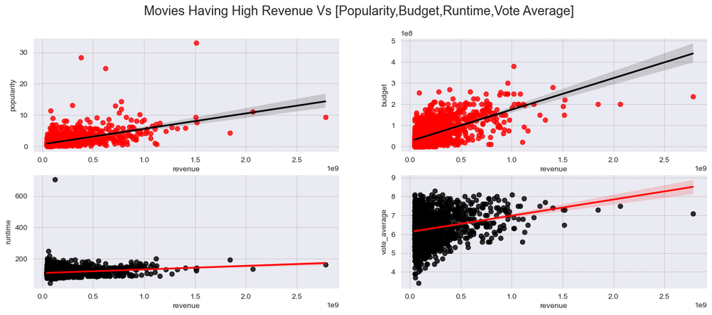

```python
fig, axes = plt.subplots(2,2,figsize = (16,6))
regplot('red','black','popularity',axes[0][0])
regplot('red','black','budget',axes[0][1])
regplot('black','red','runtime',axes[1][0])
regplot('black','red','vote_average',axes[1][1])
```

### Q10. Which month of the year are most movies released?

#### Highest number of releases happen during the month of september.

Here I extracted the Months from the released_date variable and added it to a new column named months_number.

```python
release = clean_df_tmdb.copy()
release['months_number'] = pd.to_datetime(release['release_date']).dt.strftime('%m')
```

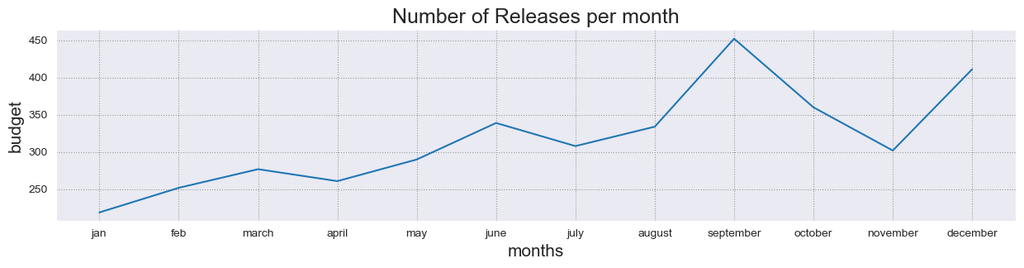

```python
plt_1 = plt.figure(figsize=(15, 3))
x = ['jan','feb','march','april','may','june','july','august','september','october','november','december']
y =release.groupby('months_number')['imdb_id'].count()
plt.plot(x,y)
plt.title('Number of Releases per month',fontsize=18)
plt.xlabel('months',fontsize=15)
plt.ylabel('budget',fontsize=15)
plt.show()
```

### Q11. Which Month Made The Highest Average Revenue?

#### Movies released in the month of May and June have the highest revenue compared to the other months.

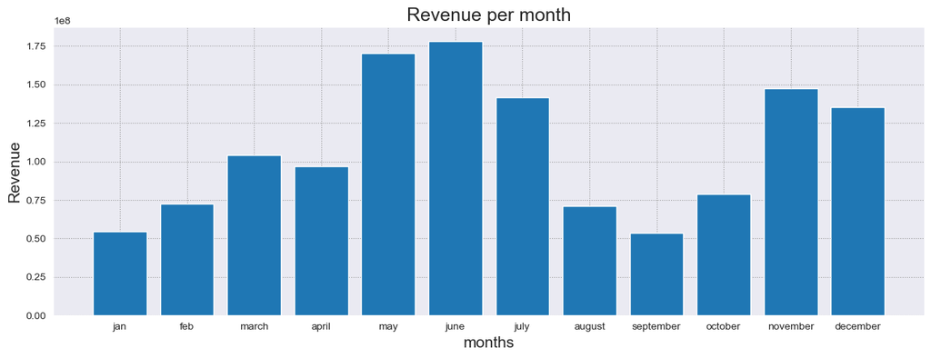

```python
plt_1 = plt.figure(figsize=(15, 5))
x = ['jan','feb','march','april','may','june','july','august','september','october','november','december']
y =release.groupby('months_number')['revenue'].mean()
plt.bar(x,y)
plt.title('Revenue per month',fontsize=18)
plt.xlabel('months',fontsize=15)
plt.ylabel('Revenue',fontsize=15)
plt.show()
```

# Limitations

- The currency of the budget and revenue were not specified in the documentation.
- A column based on **"The Movie Industry"** would have been great for extracting better insights from the data set.
- **"The Movie Industry"** would contain values like :

Hollywood,Bollywood,Chinese Cinema,United Kingdom of Great Britain,Japanese Cinema (Nihon Eiga), and many more.

### Note:

The result of analysis process might not be completely error free.

# References

- https://github.com/deepak525/Investigate_TMDb_Movies - used for finding some questions for explanatory data analysis.
- https://www.geeksforgeeks.org/matplotlib-tutorial/ - refered for some syntax,definitions.
- https://seaborn.pydata.org/ - refered for visualisation